# Lab3_OP_LRmodel

## **Lab-3** Assignment *(Making ML model of Linear Regression)* :

In this Lab🔬 or Report📚 , we have to perform a univariate linear regression with the [California Housing🏡 Prices Dataset](https://www.kaggle.com/datasets/camnugent/california-housing-prices) from [Kaggle](https://www.kaggle.com/). Now that we are focusing on a univariate linear regression model, a key concept in predicting outcomes. Our task is to run three separate models, each pairing with the median house value (dependent variable) with a different independent variable `given below` . It's like exploring three unique aspects of the data to see how they influence house values. This hands-on exercise will help us in uncovering patterns and relationships within the data using the power of linear regression. Let's get started on this insightful journey!!

**- Om Patel (8958837)**

### 🌞 Goals to Achieve:

We have to make 3 different models using in total 4 variables, that includes 👇👇👇

- median_house_value
- median_income
- population
- households

with the help of these four variables, we have to make model that can predict the values of house given any single value of **median_income, population, or households**. By doing such thing, we are able to design the Machine Learning model that can predict the values of House in California given sertain features. This application can be very helpful for individuals who are willing to by House in the regions of California.

[figure not shown]

***predicted prices are not exact as the currenty market rates.***

### 📊 Basic EDA on Dataset:

Lets, better understand the data by implementing some Exploratory Data Analysis. This will help us gain insites of the Data.

```python
import pandas as pd
import matplotlib.pyplot as plt
from sklearn.linear_model import LinearRegression
from sklearn.metrics import mean_absolute_error, mean_squared_error, explained_variance_score, r2_score
import seaborn as sns
import numpy as np
```

```python
df = pd.read_csv("S:\Conestoga\Learning_Subject\Foundation_of_ML\Labs\Lab1\CSCN8010-labs\data\housing.csv")
df.head()
```

|  | longitude | latitude | housing_median_age | total_rooms | total_bedrooms | population | households | median_income | median_house_value | ocean_proximity |
| --- | --- | --- | --- | --- | --- | --- | --- | --- | --- | --- |
| 0 | -122.23 | 37.88 | 41.0 | 880.0 | 129.0 | 322.0 | 126.0 | 8.3252 | 452600.0 | NEAR BAY |
| 1 | -122.22 | 37.86 | 21.0 | 7099.0 | 1106.0 | 2401.0 | 1138.0 | 8.3014 | 358500.0 | NEAR BAY |
| 2 | -122.24 | 37.85 | 52.0 | 1467.0 | 190.0 | 496.0 | 177.0 | 7.2574 | 352100.0 | NEAR BAY |
| 3 | -122.25 | 37.85 | 52.0 | 1274.0 | 235.0 | 558.0 | 219.0 | 5.6431 | 341300.0 | NEAR BAY |
| 4 | -122.25 | 37.85 | 52.0 | 1627.0 | 280.0 | 565.0 | 259.0 | 3.8462 | 342200.0 | NEAR BAY |

```python
df.describe()
```

|  | longitude | latitude | housing_median_age | total_rooms | total_bedrooms | population | households | median_income | median_house_value |
| --- | --- | --- | --- | --- | --- | --- | --- | --- | --- |
| count | 20640.000000 | 20640.000000 | 20640.000000 | 20640.000000 | 20433.000000 | 20640.000000 | 20640.000000 | 20640.000000 | 20640.000000 |
| mean | -119.569704 | 35.631861 | 28.639486 | 2635.763081 | 537.870553 | 1425.476744 | 499.539680 | 3.870671 | 206855.816909 |
| std | 2.003532 | 2.135952 | 12.585558 | 2181.615252 | 421.385070 | 1132.462122 | 382.329753 | 1.899822 | 115395.615874 |
| min | -124.350000 | 32.540000 | 1.000000 | 2.000000 | 1.000000 | 3.000000 | 1.000000 | 0.499900 | 14999.000000 |
| 25% | -121.800000 | 33.930000 | 18.000000 | 1447.750000 | 296.000000 | 787.000000 | 280.000000 | 2.563400 | 119600.000000 |
| 50% | -118.490000 | 34.260000 | 29.000000 | 2127.000000 | 435.000000 | 1166.000000 | 409.000000 | 3.534800 | 179700.000000 |
| 75% | -118.010000 | 37.710000 | 37.000000 | 3148.000000 | 647.000000 | 1725.000000 | 605.000000 | 4.743250 | 264725.000000 |
| max | -114.310000 | 41.950000 | 52.000000 | 39320.000000 | 6445.000000 | 35682.000000 | 6082.000000 | 15.000100 | 500001.000000 |

```python
df.info()
```

```
<class 'pandas.core.frame.DataFrame'>
RangeIndex: 20640 entries, 0 to 20639
Data columns (total 10 columns):
 #   Column              Non-Null Count  Dtype
---  ------              --------------  -----
 0   longitude           20640 non-null  float64
 1   latitude            20640 non-null  float64
 2   housing_median_age  20640 non-null  float64
 3   total_rooms         20640 non-null  float64
 4   total_bedrooms      20433 non-null  float64
 5   population          20640 non-null  float64
 6   households          20640 non-null  float64
 7   median_income       20640 non-null  float64
 8   median_house_value  20640 non-null  float64
 9   ocean_proximity     20640 non-null  object
dtypes: float64(9), object(1)
memory usage: 1.6+ MB
```

```python
# finding any null values in data
df.isnull().sum()
```

```
longitude               0
latitude                0
housing_median_age      0
total_rooms             0
total_bedrooms        207
population              0
households              0
median_income           0
median_house_value      0
ocean_proximity         0
dtype: int64
```

```
                                             Conclusion of Exploratory Data Analysis
```

### 1. ✨**Univariate Linear Regression** using Median_Income to predict Value of House✨

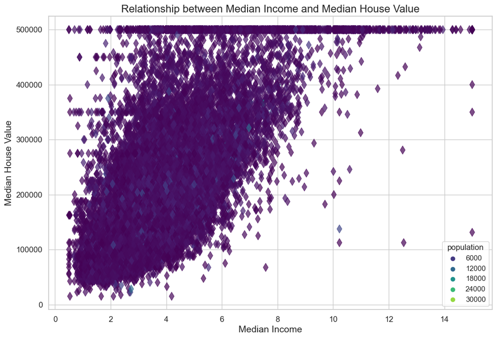

```python
sns.set(style="whitegrid")
plt.figure(figsize=(12, 8))
scatter_plot = sns.scatterplot(x="median_income", y="median_house_value", data=df, alpha=0.7, marker='d', hue="population", palette="viridis", edgecolor=None, s=80)
plt.title("Relationship between Median Income and Median House Value", fontsize=16)
plt.xlabel("Median Income", fontsize=14)
plt.ylabel("Median House Value", fontsize=14)
plt.xticks(fontsize=12)
plt.yticks(fontsize=12)
plt.show()
```

👆👆👆 The above graph shows the relationship between **Median Income** and **Median House Value**. By just observing this graph, we can say that an  
individual having **60K USD** of income can probably have Median House Value of around **300K USD**.

```python
x1 = df[["median_income"]]
y1 = df[["median_house_value"]]
model = LinearRegression()
```

```python
model.fit(X=x1, y=y1)
```

```
LinearRegression()
```

```python
exmp1 = x1
ypredict_1 = model.predict(exmp1)
```

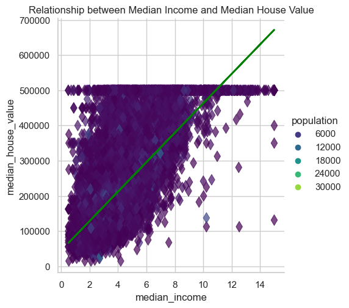

```python
plt.figure(figsize=(100,100))
sns.relplot(x = "median_income", y = "median_house_value", data=df, alpha=0.7, marker='d', hue="population", palette="viridis", edgecolor=None, s=80)
plt.plot(exmp1, ypredict_1, color='green', linewidth=2)
plt.title('Relationship between Median Income and Median House Value')
plt.show()
```

```python
print(f"The Mean Absolute error is {mean_absolute_error(y1, ypredict_1)}")
print(f"The Mean squared error is {mean_squared_error(y1, ypredict_1)}")
print(f"Variance score is {explained_variance_score(y1, ypredict_1)}")
print(f"R2 Score is {r2_score(y1, ypredict_1)}")
```

```
The Mean Absolute error is 62625.9337911434
The Mean squared error is 7011311502.929527
Variance score is 0.4734474918071989
R2 Score is 0.47344749180719903
```

Now Let's Understand those numbers...

Lets understand why data point are limited at around $500000.

```python
count = 0
for i in df["median_house_value"]:
    if i >=499999:
        count += 1
print(count)
```

```
992
```

This shows that there are 992 observations which is around $500000, Hence we can conclude that, due to higher no of observation at that point we can see the coloction of examples at that point.

***This is the the same case for each variable and each example***

Now, Lets calculate the value of Intercept point and Slope...

[figure not shown]

```python
print(model.intercept_)
print(model.coef_[0])
```

```
[45085.57670327]
[41793.8492019]
```

### 2. ✨ **Univariate Linear Regression** using population and house value.✨

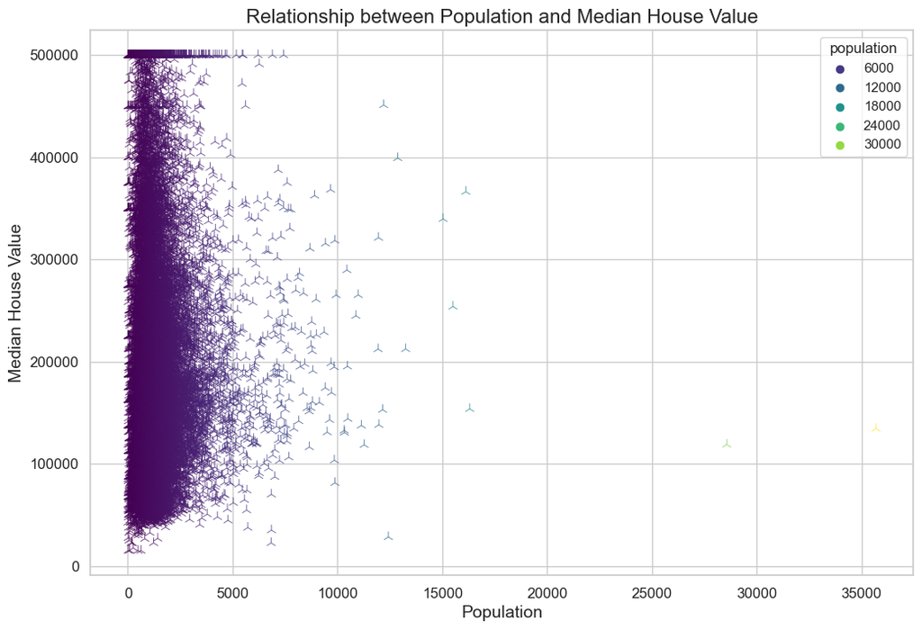

```python
sns.set(style="whitegrid")
plt.figure(figsize=(12, 8))
sns.scatterplot(x="population", y="median_house_value", data=df, alpha=0.7, marker='2', hue="population", palette="viridis", edgecolor=None, s=80)
plt.title("Relationship between Population and Median House Value", fontsize=16)
plt.xlabel("Population", fontsize=14)
plt.ylabel("Median House Value", fontsize=14)
plt.xticks(fontsize=12)
plt.yticks(fontsize=12)
plt.show()
```

We can see most of the population ranges between 0 to 10000 peoples.

```python
x2 = df[["population"]]
y2 = df[["median_house_value"]]
model = LinearRegression()
```

```python
model.fit(X=x2, y=y2)
```

```
LinearRegression()
```

```python
examp2 = x2
ypredict_2 = model.predict(examp2)
```

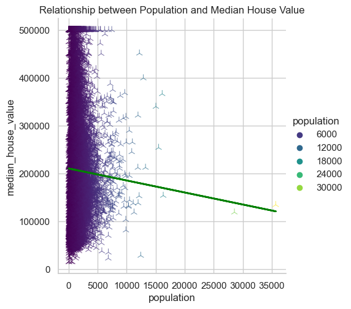

```python
plt.figure(figsize=(100,100))
sns.relplot(x = "population", y = "median_house_value", data=df, alpha=0.7, marker='2', hue="population", palette="viridis", edgecolor=None, s=80)
plt.plot(examp2, ypredict_2, color='green', linewidth=2)
plt.title('Relationship between Population and Median House Value')
plt.show()
```

Now, This is the interesting case As you can see the majority of population of a block is between 0 to 7000. However, the prediction of this model not say the same thing. Techicnally, it should draw a lineamong those points but there is a Block which has the population of 36000. So, due to this the model got confussed and wrongly predict outcomes.

```python
print(f"The Mean Absolute error is {mean_absolute_error(y2, ypredict_2)}")
print(f"The Mean squared error is {mean_squared_error(y2, ypredict_2)}")
print(f"Variance score is {explained_variance_score(y2, ypredict_2)}")
print(f"R2 Score is {r2_score(y2, ypredict_2)}")
```

```
The Mean Absolute error is 91153.82009473183
The Mean squared error is 13307412412.389355
Variance score is 0.0006076066693255777
R2 Score is 0.0006076066693256887
```

Now Let's Understand those numbers...

```python
print(model.intercept_)
print(model.coef_[0])
```

```
[210436.26207627]
[-2.51175277]
```

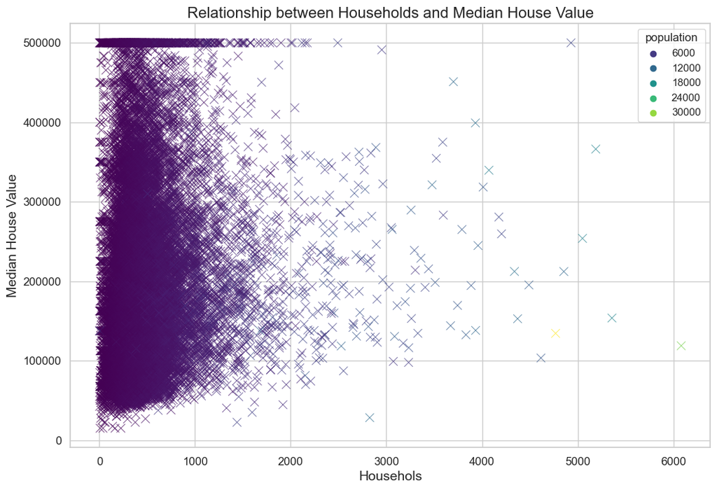

```python
sns.set(style="whitegrid")
plt.figure(figsize=(12, 8))
sns.scatterplot(x="households", y="median_house_value", data=df, alpha=0.7, marker='x', hue="population", palette="viridis", edgecolor=None, s=80)
plt.title("Relationship between Households and Median House Value", fontsize=16)
plt.xlabel("Househols", fontsize=14)
plt.ylabel("Median House Value", fontsize=14)
plt.xticks(fontsize=12)
plt.yticks(fontsize=12)
plt.show()
```

```python
x3 = df[["households"]]
y3 = df[["median_house_value"]]
model_households = LinearRegression()
```

```python
model_households.fit(X=x3, y=y3)
```

```
LinearRegression()
```

```python
example_3 = x3
ypredict_3 = model_households.predict(example_3)
```

[figure not shown]

```python
plt.figure(figsize=(100,100))
sns.relplot(x = "households", y = "median_house_value", data=df, alpha=0.7, marker='2', hue="population", palette="viridis", edgecolor=None, s=80)
plt.plot(examp2, ypredict_2, color='green', linewidth=2)
plt.title('Relationship between Households and Median House Value')
plt.show()
```

```python
print(f"The Mean Absolute error is {mean_absolute_error(y3, ypredict_3)}")
print(f"The Mean squared error is {mean_squared_error(y3, ypredict_3)}")
print(f"Variance score is {explained_variance_score(y3, ypredict_3)}")
print(f"R2 Score is {r2_score(y3, ypredict_3)}")
```

```
The Mean Absolute error is 90802.74324318448
The Mean squared error is 13257776904.728533
Variance score is 0.0043352546340906795
R2 Score is 0.0043352546340906795
```

Now Let's Understand those numbers...

```python
print(model_households.intercept_)
print(model_households.coef_[0])
```

```
[196928.57716233]
[19.87277516]
```

### ✨ Summary of the Report. ✨

Among the all three models the 1 one is the most optimal and has best good ness of fit. the other onvs have some biseness or outliers. We can understand that by following table

| Model | Mean Absolute Error | Mean Squared Error | Variance Score | R2 Score |
| --- | --- | --- | --- | --- |
| Model1 (median income) | 62625.93 | 7011311502.93 | 0.4734 | 0.4734 |
| Model2 (population) | 91153.82 | 13307412412.39 | 0.0006 | 0.0006 |
| Model3 (number of households) | 90802.74 | 13257776904.73 | 0.0043 | 0.0043 |

Among the three models, Model1 demonstrates the best performance, as indicated by lower MAE and MSE values, along with a relatively higher Variance Score and R2 Score. Model2 and Model3 exhibit higher errors and lower predictive power compared to Model1. Further analysis and refinement may be necessary to enhance the predictive capabilities of the models.